# STA 141 Final Project

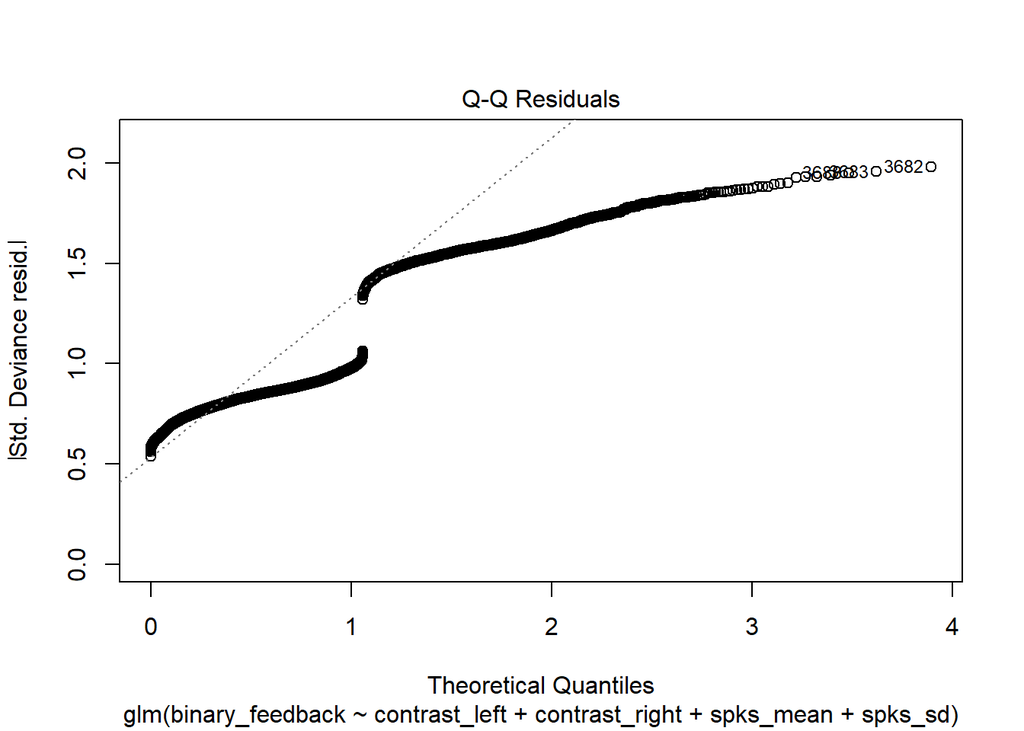

The residuals versus fitted values plot reveals that the data deviates from a perfectly centered, horizontal line at zero, indicating potential bias in the model’s predictions. However, as the predicted values increase, the residuals tend to align more closely with the horizontal line, suggesting improved model fit for higher predictions. Additionally, two outliers are noticeable—one around a predicted value of 1.9 and another with a Pearson residual of approximately -2.5—indicating points where the model’s errors are more pronounced.

```
##
## Call:
## glm(formula = binary_feedback ~ contrast_left + contrast_right +
##     spks_mean + spks_sd, family = "binomial", data = session_all)
##
## Coefficients:
##                Estimate Std. Error z value Pr(>|z|)
## (Intercept)     0.04403    0.44579   0.099   0.9213
## contrast_left   0.15483    0.08017   1.931   0.0535 .
## contrast_right -0.12072    0.08218  -1.469   0.1418
## spks_mean      18.74535   13.44198   1.395   0.1632
## spks_sd         1.10964    4.65296   0.238   0.8115
## ---
## Signif. codes:  0 '***' 0.001 '**' 0.01 '*' 0.05 '.' 0.1 ' ' 1
##
## (Dispersion parameter for binomial family taken to be 1)
##
##     Null deviance: 6118.2  on 5080  degrees of freedom
## Residual deviance: 6044.4  on 5076  degrees of freedom
## AIC: 6054.4
##
## Number of Fisher Scoring iterations: 4
```

The GLM output shows contrast_left has a borderline significant positive effect (p = 0.0535), while contrast_right shows a negative but insignificant effect. spks_mean and spks_sd aren’t significant predictors. The small deviance reduction suggests limited model improvement. To enhance performance, we should consider checking for multicollinearity, adding interaction terms, exploring alternative models, or adjusting the link function.

```
##
## Call:
## lm(formula = feedback_type ~ contrast_left + contrast_right +
##     spks_mean + spks_sd, data = session_all_clean)
##
## Residuals:
##     Min      1Q  Median      3Q     Max
## -1.7600 -1.3027  0.5187  0.6217  0.8417
##
## Coefficients:
##                 Estimate Std. Error t value Pr(>|t|)
## (Intercept)     0.006064   0.182652   0.033   0.9735
## contrast_left   0.062348   0.032171   1.938   0.0527 .
## contrast_right -0.048759   0.033479  -1.456   0.1453
## spks_mean       5.156517   5.287690   0.975   0.3295
## spks_sd         1.214781   1.870825   0.649   0.5162
## ---
## Signif. codes:  0 '***' 0.001 '**' 0.01 '*' 0.05 '.' 0.1 ' ' 1
##
## Residual standard error: 0.9014 on 5076 degrees of freedom
## Multiple R-squared:  0.01413,    Adjusted R-squared:  0.01335
## F-statistic: 18.19 on 4 and 5076 DF,  p-value: 7.631e-15
```

```
##  contrast_left contrast_right      spks_mean        spks_sd
##       1.004647       1.040022      26.566205      26.696420
```

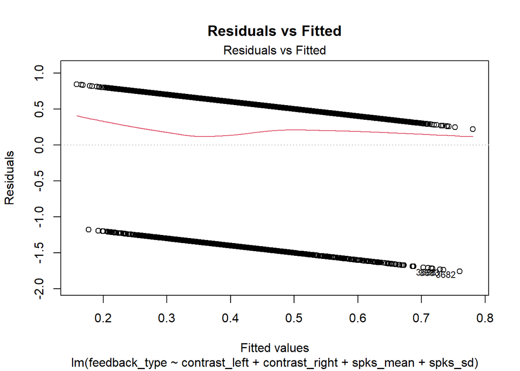

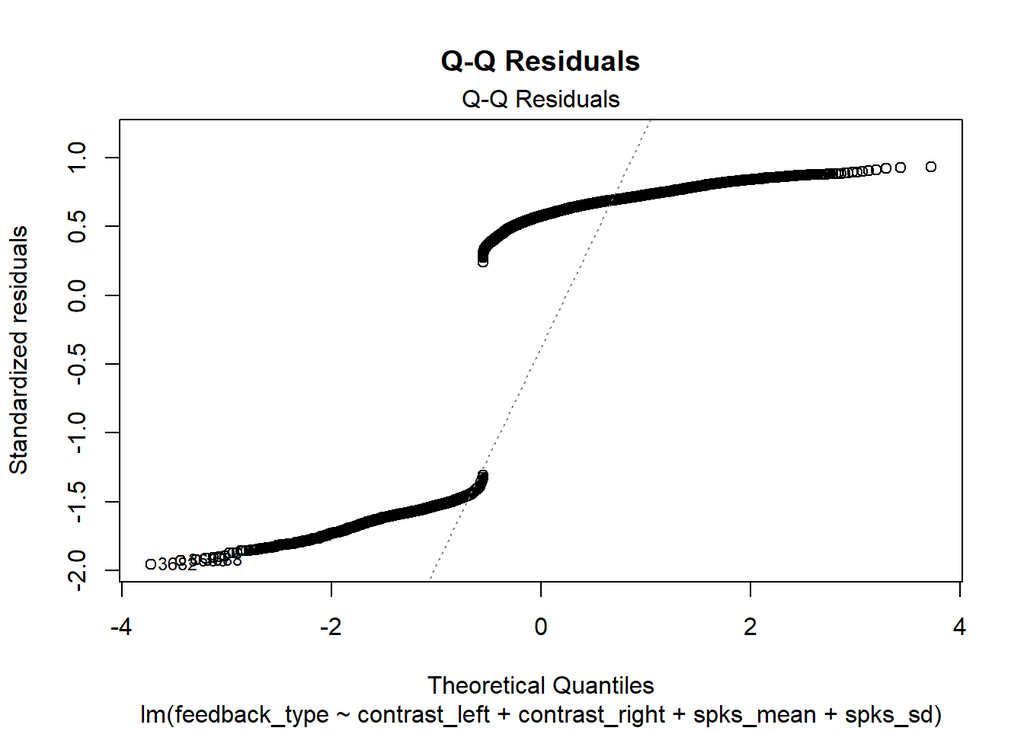